# BEE2038 - Second tutorial - Instructor’s guide

# 1 Overview

I proposed we cover material from the [Mock midterm exam](https://vle.exeter.ac.uk/pluginfile.php/1435123/mod_resource/content/1/_book/ps.html#mock-mid-term-exam).

I asked students to give me feedback on which they wanted covered but I haven’t heard from them yet. Thus I suggest we:

- ask the students at the beginning of tutorial, and let’s be prepared to discuss ANY of these,
- make sure to involve the students… go around the room and ask them to answer pieces of the question (or discuss individual answer choices); engage them in the logic,
- make the logic and the marking for the MCQ’s clear.

*Below I also highlight the questions I would focus on if the students don’t have strong opinions*.

# 2 Questions to focus on

**Start with the questions on demand/demand curves** and their characteristics (so we are really moving on from last week)

3.0.9 (Price change net effect): 6-8 minutes. Probably worth drawing this on the board

3.0.10 (Where is substitution the greatest): 7-8 minutes. This one is challenging!

3.0.11 (Which choice is *not* optimal… cider/beer): 5-7 minutes. This is particularly challenging because

- of the option to consider ‘corner solutions’
- because of the logic of the question wording

**Now we return to preferences/utility/indifference curves**

3.0.5 (Properties of utility functions): 4 minutes max. Focus on why C is correct (explaining the ‘mathy’ notation) and on why E is *not correct*.

Also point out that some questions that ask you to ‘Choose all that are correct’ may in fact have only a *single* correct answer.

**Time-permitting, some questions about empirical work, causality, etc.**

3.0.3 (Estimating a supply curve): 4 minutes max. The key insight is that we need a constant supply curve and a shifting demand curve to observe and estimate the supply curve.

3.0.4 (Causality, educational lottery): 4 minutes max. Get students to discuss and explain why this *does* represent reasonable causal evidence

# 3 Mock exam, with instructor guidelines

### 3.0.1

Choose ONE. Which of the following best represents ‘repeated cross-sectional firm-level micro-data that may be used to test whether firms that engage in CSR (corporate social responsibility) activities tend to be in more heavily-regulated industries’?

1. A table of the average number of employees engaged in CSR per firm, estimates of the regulatory involvment, and amount spent on political lobbying in 2017, aggregated across the largest employment sectors: professional services, manufacturing, and retail.
2. A data set with ten observations, one for each of the years 2010-2018 for a single small firm. Each observation (row) contains ten variables (columns) detailing the CSR expenditure, profit, and estimated regulatory burden for this firm, based on a survey on their CSR activities and spending, cross-checked against their public financial reportings.
3. A dataset of US firms between the years 1990-2015. Each year a different representative sample of 1000 firms are chosen and given a survey on their CSR activities and spending, cross-checked against their public financial reportings. Each firm’s 4-digit SIC industry code is reported and merged to an independent measure of regulatory burden by industry by year.
4. A dataset of individual tax reportings (income, asset balances and liabilities, corporate taxes paid, dividends paid, inventory depreciation, loan interest, salaries and national insurance payments, and tax-favored capital investment and research) from all small UK firms between the years 1950-2015.
5. An excerpt of the findings from a report on the tax and regulatory burden and CSR activities of EU-based firms between 1970 and 2015.

Correct: C. A dataset of US firms between the years 1990-2015. Each year a different representative sample of 1000 firms are chosen and given a survey on their CSR activities and spending, cross-checked against their public financial reportings. Each firm’s 4-digit SIC industry code is reported and merged to an independent measure of regulatory burden by industry by year.

Note, the other choices depict, respectively: a. aggregated data (not micro-data, not firm-level data) b. a panel dataset not repeated cross-section. Also not particular useful for testing this relationship; one firm will not lead to any variation in ‘which industry’ d. Panel data. More importantly, it doesn’t seem to have any information on CSR or on regulatory burden. e. This is a *report* not data.

By the way, note that the question about CSR is not a ‘causal question’; just a question about an observed relationship.

**Instructors**: this is a challenge question. Students may wonder ‘how was I supposed to know this’? In response, point out that ‘understanding data and how economists use it’ was discussed in the latter part of the ‘math tools’ section of the web book, and in suggested readings linked within this.

### 3.0.2

*(Choose ONE)* Which of the following fields of Economics typically uses the most pure mathematics?

1. Applied microeconomics
2. Empirical labour economics
3. Microeconomic theory
4. Macroeconomics of growth
5. Development economics

Microeconomic theory. Although you may be used to thinking of ‘theory’ as a bunch of woolly verbiage, in Economics it involves very formal mathematics (especially Real Analysis) and logic.

### 3.0.3 (Estimating a supply curve)

*(Choose all that are correct, and no more.)* Suppose we observe prices and quantities traded in a market over a period of time. In such a case, fitting a line through these points will provide a reasonable valid estimate of a market *supply* curve... (Choose ALL that are *necessary* for this.)

1. if the supply curve was constant over this period.
2. if this was a period when the demand curve was constant and the supply curve was shifting.
3. if this data pertains to several dissimilar products, and we cannot separate these products in the data set.
4. if the demand curve shifted over this period.
5. if the supply curve is approximately linear.

TRUE: a. if the supply curve was constant over this period.

4. if the demand curve shifted over this period.
5. if the supply curve is approximately linear.

False:

“if this was a period when the demand curve was constant and the supply curve was shifting.” — this is a condition for estimating a *demand* curve not a supply curve.

“if this data pertains to several dissimilar products, and we cannot separate these products in the data set.” —With several unrelated products it is unclear what this relationship would be depicting

### 3.0.4 (evidence on returns to university)

*Choose ONE.* Suppose that, over a number of years, a country randomly (by lottery) selected people from an eligible pool to attend university, and all who were selected attended university, and all who were not selected did not attend any university. Suppose that, for this country, on average those who attended university earned significantly more than those who did not. In such a case, which of the following statements is most correct?

1. This offers no valid evidence on the income returns to education because correlation is not causation.
2. This provides substantial evidence that attending university leads to higher wages, at least in the context of this country.
3. This proves that if one’s parents earn a higher wage one is more likely to attend university, at least in the context of this country.
4. This provides substantial evidence that education is a luxury good.
5. None of the above

TRUE: (b) This provides substantial evidence that attending university leads to higher wages, at least in the context of this country.

*Discussion:* This seems to describe an ideal ‘natural experiment’ for testing the impact of attending university on earnings, all else equal. In this case it *is* reasonable to infer a causal relationship!

FALSE: all other answers...

Yes, ‘correlation is not causation’ but that doesn’t invalidate this evidence. ...

There was nothing mentioned about parents...

A luxury good is basically one where a “1%” increase in income leads to a larger than 1% increase in amount of the good consumed. ... here the causality is in the opposite direction, and anyways this is a different issue.

**UTILITY AND CHOICE**

### 3.0.5 (Ordinal utility functions)

*(Choose all that are correct, and no more.)* According to the standard classical assumptions over *ordinal* utility functions and over budget constraints:

1. We can observe whether an individual’s utility increases over time by recording their happiness.
2. Utility functions are expressed as a direct function of prices and income, holding the quantity of goods consumed $(x_1,x_2,...,x_n$) constant .
3. For a utility function in $n$ goods $u(x_1,x_2,...,x_n)$ the combinations of $(x_1,x_2,...x_n)$ that yield a particular utility level all lie on the same ‘indifference curve.’ An individual utility function implies an infinite number of indifference curves.
4. Utility functions are ‘homogenous of degree zero’: doubling all arguments will lead to the same level of utility.
5. Maximising a utility function $U(x,y)$ subject to a budget constraint $p_xX + p_yY \leq I$ will yield the same choices (of x and y) as maximizing this same utility function subject to the budget constraint $100p_xX + 100p_yY \leq I$, i.e, multiplying prices by 100 but leaving income unchanged.

TRUE: c. For a utility function in $n$ goods $u(x_1,x_2,...,x_n)$ the combinations of $(x_1,x_2,...x_n)$ that yield a particular utility level all lie on the same ‘indifference curve.’ An individual utility function implies an infinite number of indifference curves.

Other answers are false... respectively

a. The standard view of utility functions is that they are *not* directly measurable

b. No, utility functions are a function of the goods and services consumed. (Here we are describing *indirect* utility, which we did not cover)

d. Utility functions are not Homogenous of degree zero (*demand functions* are)

e. The statement would only be correct if we *also* multiplied income by 100. Otherwise they certainly cannot choose the same amounts of each , they wouldn’t be able to afford it.

Recall ‘ordinal’ utility is what we have been focusing on. We can essentially only observe individual’s choices and make inferences about ‘what things they preferred more than other things.’

### 3.0.6

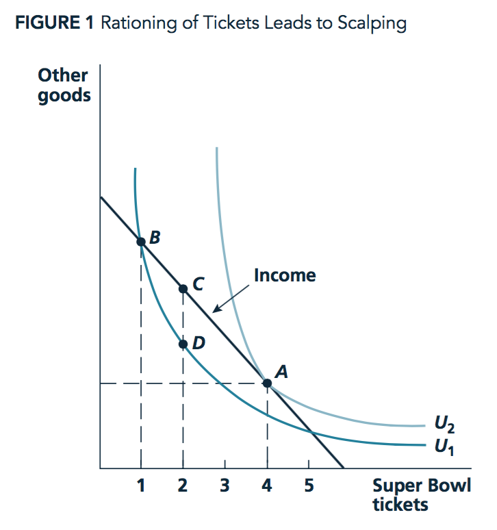

*Choose TWO. Partial credit will NOT be awarded.* Suppose the NFL had a ‘rationing policy’, where each consumer could buy at most one ticket to the Super Bowl. Suppose the diagram above represents each consumer’s budget constraint and two of her indifference curves. The maximum amount she would be willing to pay to buy an additional (second) ticket is characterised by the vertical distance between (______________)

and

(____________)

(choose two):

1. A
2. B
3. C
4. D

### 3.0.7

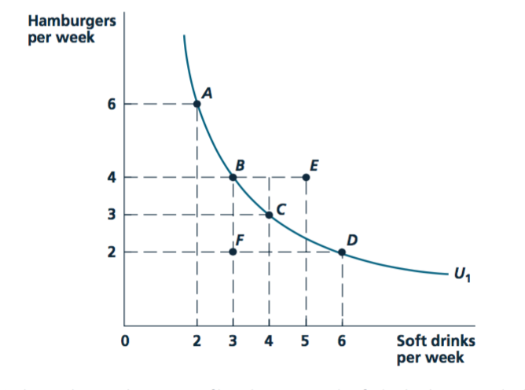

*(Choose all that are correct, and no more.)* Considering the above indifference curve, which of the following are true?

1. At point A she is willing to give up approximately 2 hamburgers to gain 1 soft drink.
2. At point D she is willing to give up more than one hamburger to gain one soft drink.
3. For this consumer, these goods are perfect complements, although not at a 1-1 ratio.
4. This consumer would strictly prefer to consume at point C than to consume at point A.
5. The indifference curve demonstrates an *diminishing* marginal rate of substitution between the two goods; at a higher level of hamburger consumption, she requires *fewer* soft drinks to be willing to give up a hamburger.

True statements:

1. At point A she is willing to give up approximately 2 hamburgers to gain 1 soft drink

*and*

5. The indifference curve demonstrates an *diminishing* marginal rate of substitution between the two goods; at a higher level of hamburger consumption, she requires *fewer* soft drinks to be willing to give up a hamburger.

### 3.0.8

If, starting from any level of consumption (with a positive consumption of plankton), a individual can hold her utility constant by reducing her consumption of plankton by 1 and increasing her consumption of algae by 10, then, for this individual, algae and plankton are (select only one):

1. perfect substitutes
2. perfect complements
3. complements (but not perfect complements)
4. substitutes (but not perfect substitutes)
5. inferior goods

perfect substitutes.

*Note*: remember that perfect substitutes require the MRS to be a *constant* ratio, but that ratio need not be 1:1.

**DEMAND, ITS DERIVATION AND ITS PROPERTIES**

### 3.0.9 (Price change net effect)

*(Choose all that are correct, and no more.)*

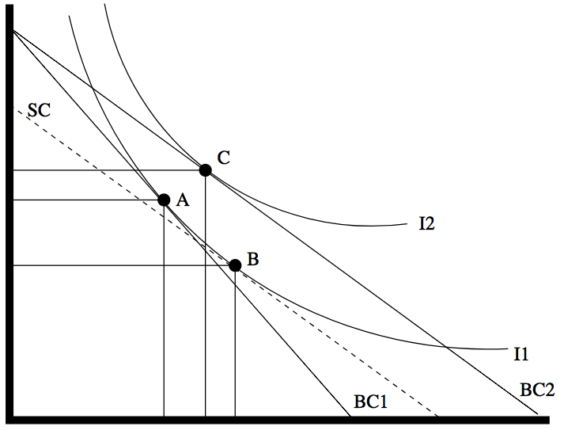

The diagram above depicts two of an individual’s indifference curves and depicts her budget constraint before and after a price decrease, as well as the compensated budget constraint at the initial point. For this individual, within this range of prices, and for this income level, we know that good X (*Clarification: good X is the good depicted on the horizontal axis*) can be classified as:

1. a normal good
2. an inferior good
3. a Giffen good
4. a useless good
5. a luxury good

an inferior good

*Discussion:* The movement between the choice made given the (hypothetical) budget constraint SC and the actual ‘new’ budget constraint BC2 depicts the income effect of the price change. Note that this movement is the same as would occur from an increase in income given the new price ratio.

Over this range we see that this ‘hypothetical increase in income’ leads to a decrease in consumption of the X good... the horizontal movement from B to C. Thus in this range it’s an inferior good. Note that as it’s inferior it cannot be normal or luxury.

However, the net effect of decrease in the price of the X good (including substitution and income effects) is the movement from A to C. This is an *increase* in the consumption of the X good, so it is not Giffen. (The substitution effect outweighed the income effect.)

The x good is not ‘useless’ as the indifference curves are not horizontal.

### 3.0.10 (Where is substitution the greatest)

*Choose ONE.* Which of the following functional forms for utility suggests the greatest substitution effect of a 0.20 increase in the price of X when starting from the point where $P_X =P_Y-0.10$?

1. $U(X,Y) =2X+2Y$
2. $U(X,Y) = XY$
3. $U(X,Y) = 2 \times min(X,Y)$
4. $U(X,Y)=X^4Y^3$
5. $U(X,Y)=Y$

$U=2X+2Y$

*Discussion:* This is a challenging question.

We can rule out some of these immediately.

$U(X,Y)=Y$ implies only good Y is valued, so no substitution is possible... and in fact the price change in X will have no impact

Choice (a) $U(X,Y) =2X+2Y$ stands out. This is ‘perfect substitutes’ (here at ratio 1:1) . For this case the consumer chooses the good with greater ‘bang for the buck’ (MU/p). Either this ‘better BftB’ is the same before and after the price change (in which case there’s no change), or it switches to the other good, leading to the ‘maximum possible substitution.’ Here both X and Y have the same MU, so the consumer will simply choose the cheaper one. Before the increase X was cheaper, but afterwards Y is cheaper. $\rightarrow$ maximum possible substitution!

Finally, consider the utility functions $U(X,Y) = XY$ and $U(X,Y)=X^4Y^3$. These are basically U-shaped (in fact they are Cobb-douglas), so there will be *some substitution effect.* However, for these, for any positive price of each good a positive amount of each will be consumed. (Why? Because otherwise you get *no utility*!) So the substitution will not be ‘a complete switch from one good to the other.’

### 3.0.11 (Which choice is *not* optimal)

*(Choose all that are correct, and no more.)* Suppose, at a particular consumption choice that an individual is considering, her MRS (of cider for beer) is 2:1. That is, at this point under consideration she is willing to give up 2 ciders to gain an extra beer. This choice is definitely *not* *optimal* *if*

1. the price of beer is less than the price of cider, and the choice being considered involves a positive amount of cider.
2. the price of beer is more than twice the price of cider, and this choice involves consuming both beer and cider.
3. the price of beer is more than three times the price of cider
4. there are goods that give her utility other than beer and cider.
5. the price of beer is exactly twice that of cider.

NOT optimal if:

the price of beer is less than the price of cider, and the choice being considered involves a positive amount of cider.

Nor if the price of beer is more than twice the price of cider, and this choice involves consuming both beer and cider. (or actually, if it involves consuming any beer)

*Discussion:* At this point, at the margin (i.e., considering very small adjustments) she values beer twice as much as cider. Thus, if this point involves consuming both beer and cider, it can only be optimal if the price of beer is twice that of cider. If the relative price of beer:cider is less than 2:1 she should move towards consuming more beer and less cider. If the relative price appears more than this, she should move towards consuming less beer and more cider.

However, if the price of beer is less than twice that of cider and she is consuming no cider than this still may be optimal as she cannot consume ‘less than zero cider’.

Similarly, if the price of beer is more than twice that of cider and she is consuming no beer than this still may be optimal as she cannot consume ‘less than zero beer’.

*Remember* to read the questions carefully; note that this question is asking for conditions such that a particular choice is *NOT* optimal.

### 3.0.12

*(Choose ONE)* Suppose the economy consists of five consumers, each of whom have an individual demand curve for figs equal to $q_d(p) = 10-p$. Which of the following represents the *market demand* for figs:

1. $Q_d = 10-p$
2. $Q_d = 10-p$
3. $Q_d = 50-5p$
4. $Q_d = 50-p$
5. $Q_d = 50$

$Q_d = 50-5p$

*Discussion:* we simply sum the demand curves ‘horizontally’ ... I.e., at every price add the quantity demanded by each of the five consumers, so $Q_d = 5 \times q_d(p) = 5 \times(10-p) = 50-5p.$

### 3.0.13

*(Choose all that are correct, and no more.)* Which of the following will NOT *shift* the market demand curve for good X, $Q^{d}(X)$?

1. The price of good X rises.
2. The price of another good Y falls
3. The wealthiest 10% of consumers see their income fall by £10,000 each, while the least wealthy 90% of consumers see their income rise by £10,000 each, leading to no change in total income
4. Consumers’ preference for good X changes
5. Costs of producing good X fall, shifting the supply curve

*Correct choices = things that will NOT shift $Q^{d}(X)$*:

(a) The price of good X rises – NO, this represents a movement along the demand curve for X AND

(e) Costs of producing good X fall, shifting the supply curve – NO the shift in the supply curve doesn’t enter into the market demand curve

*Incorrect choices = things that will or might shift $Q^{d}(X)$*:

The price of another good Y falls: if the goods are complements then $Q^{d}(X)$ will shift out— more quantity of X demanded at every price $P_X$. If the goods are substitutes than $Q^{d}(X)$ will shift inwards.

Consumers’ preference for good X changes: Obviously this shifts the demand curve

### 3.0.14 (Pricing and demand elasticity)

*(Choose ONE)* Should a price-setting firm ever set its price at a point where demand is inelastic? Why or why not?

1. Yes, because if demand were elastic, a rise in price would reduce quantity and thus reduce revenue.
2. Yes, because revenue is maximized where demand is the most inelastic.
3. No, because if it were at such a point, it could lower its price and its revenue would increase and costs would decline.
4. No, because if it were at such a point, it could raise its price and its revenue would increase and costs would decline.

No, because if it were at such a point, it could raise its price and its revenue would increase and costs would decline.

*Discussion:* With inelastic demand, at the margin, a price increase of some percentage will cause a smaller percentage decrease in quantity demanded, and thus a rise in revenue. As less is needed to be produced, cost will also decline.

### 3.0.15

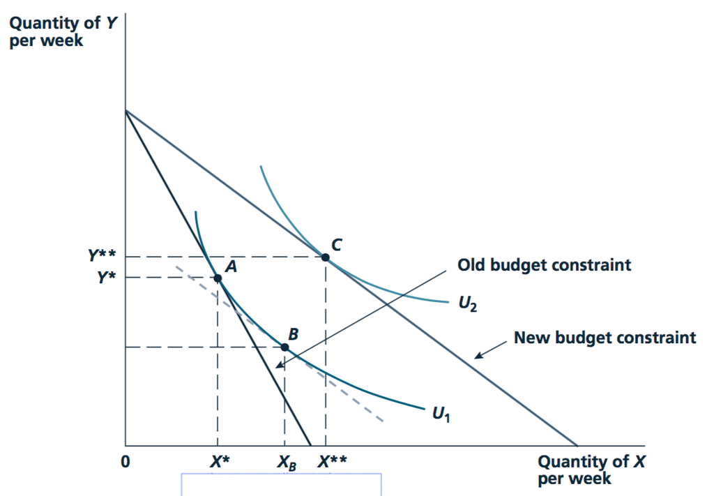

*Choose TWO. Partial credit will NOT be awarded for this question.* In the graph above, the price of X has decreased, yielding the ‘new budget constraint.’ The *income* effect of this price change (on X) is the movement between points (choose TWO):

1. 0
2. $X^{\ast}$
3. $X_B$
4. $X^{\ast\ast}$
5. $Y^{\ast}$

$X_B$ and $X^{\ast\ast}$

*Discussion:* This is straight out of the web book and textbook.

**PRODUCTION FUNCTIONS AND COSTS**

### 3.0.16

Suppose MPL = 20 and MPK = 40 and the rental rate on capital is £10. If the level of production is currently efficient (and both capital and labour are used, with an everywhere-diminishing MRTS), the wage rate must be

1. £10
2. £5
3. £20
4. £40

b: 5 pounds. The MRTS must equal the price ratio. Thus $MPL/MPK=w/r$ so here $20/40=5/10$

### 3.0.17

*(Choose all that are correct, and no more.)* Suppose the production function for good q is given by $q(K,L) = 3K + 2L$ where K and L are capital and labour inputs.

Which of the following statements are true?

1. The function exhibits constant returns to scale.
2. The function exhibits increasing returns to scale.
3. The function exhibits diminishing marginal productivity for each input (holding the other input constant).
4. The function exhibits constant marginal productivities for each input (holding the other input constant).
5. A positive amount of both inputs are required to produce a positive output.

The function exhibits constant returns to scale (doubling K and L doubles outputs, for example

*and*

The function exhibits constant marginal productivities for each input: output increases at rate 2 per labour input and at rate 3 per capital input

### 3.0.18

*(Choose all that are correct, and no more.)* Which of the following statements are correct, regarding a firm’s cost curve?

1. Total costs are the sum of fixed and variable costs
2. Economists include consumer surplus in their definition of revenues.
3. If Average Cost (AC) increases in quantity, the Average Cost (AC) curve must be above the Marginal Cost (MC) curve for each level of output.
4. The MC curve intersects the AC curve at its maximum (if a maximum exists).
5. If marginal costs are increasing and there are no fixed costs, this implies increasing AC everywhere.

TRUE: Total costs are the sum of fixed and variable cost

If marginal costs are increasing and there are no fixed costs, this implies increasing AC everywhere.

The others are false. Consumer surplus is not a part of revenue, it’s an entirely different thing.

If Average Cost (AC) increases in quantity, the Average Cost (AC) curve must be BELOW the Marginal Cost (MC) curve for each level of output.

The MC curve intersects the AC curve at its MINIMUM (if a MINIMUM exists). ... AC could be everywhere above MC if there is a fixed cost.

**Profit maximisation and supply, Perfect competition, general equilibrium and efficiency**

### 3.0.19

*(Choose ONE.)* Suppose the market demand curve for a good follows $Q_D = 100 - P$ and the market supply follows $Q_S = -10 + P$. What is the total *revenue* of firms (expenditure of consumers) on this product, in equilibrium?

1. -45
2. -1000
3. -2475
4. -3025
5. None of the above.

100-P = P-10 $\rightarrow$ 2p = 110 $\rightarrow$ P=55 $\rightarrow$ Q =

100-55=55-10=45. Revenue = Q*P = 45*55 =2475

### 3.0.20

*(Choose ONE.)* Under perfect competition, if an industry is characterized by positive economic profits in the short run

1. firms will leave the market in the long run and the short-run supply curve will shift outward.
2. firms will enter the market in the long run and the short-run supply curve will shift outward.
3. firms will enter the market in the long run and the short-run supply curve will shift inward.
4. firms will leave the market in the long run and the short-run supply curve will shift inward.

b: firms will enter the market in the long run and the short-run supply curve will shift outward.

### 3.0.21

*(Choose all that are correct, and no more.)* Markets can fail to achieve efficiency for the following reason(s)

1. There are prices consumers do not think are fair.
2. There are wages workers do not think are fair.
3. Trade puts people out of work.
4. There are barriers to entry, leading to monopolies.
5. There are too many consumers.

**PUBLIC GOODS**

### 3.0.22

*(Choose all that are correct, and no more.)* Which of the following are most reasonably considered public goods?

1. Clothing
2. A giant wedge of cheese
3. Headache medicines provided to individuals for free by the NHS
4. Useful and interesting knowledge generated from an archeological discovery
5. An earthquake-prevention system that successfully prevents earthquakes from occuring

Correct: Useful and interesting knowledge generated from an archeological discovery Correct: An earthquake-prevention system that successfully prevents earthquakes from occuring

Both of these are reasonably considered nonrival and nonexcludable, ergo Public Goods.

**END OF PAPER**